# Practical Machine Learning - Course Assignment

Alex Zukowsky

January 30, 2016

In this project, my goal will be to use data from accelerometers on the belt, forearm, arm, and dumbell of 6 participants. They were asked to perform barbell lifts correctly and incorrectly in 5 different ways.

First I started by loading the necessary libraries and the data sets. I assigned the full data set to the dataframe ‘FullData’ and the 20 test cases to the dataframe ‘FINALTest’.

```r
library(AppliedPredictiveModeling)
library(caret)
library(ElemStatLearn)
FullData <- read.csv("pml-training.csv", header = TRUE)
FINALTest <- read.csv("pml-testing.csv", header = TRUE)
```

This started me out with a data set containing a rather large number of variables (160). I did an initial view of the data set and discovered that there were several variables that were either mostly null or mostly NA. For that reason I then ran some code that removed any variable with 90% or more NA or NULL using the following code:

```r
## Remove columns with 90% NA values
FullDataTRIM <- FullData[,colSums(is.na(FullData))<0.9*nrow(FullData)]

## Remove columns with 90% NULL values
FullDataTRIM <- FullDataTRIM[,colSums(FullDataTRIM =="")<0.9*nrow(FullDataTRIM)]
```

This initial cleanup brought me down from 160 variables to just 60.

```r
## Break up our full data set into training/testing
inTrain = createDataPartition(FullDataTRIM$classe, p=3/4)[[1]]
training = FullDataTRIM[inTrain,]
testing = FullDataTRIM[-inTrain,]
```

I then reviewed the data set once more to remove variables that, logically, would have no value (name, time, etc.).

```r
training <- training[ , -which(names(training) %in% c("X", "user_name",
                          "raw_timestamp_part_1", "raw_timestamp_part_2",
                          "cvtd_timestamp", "new_window", "num_window"))]
```

This next but of cleanup left me with just 53 variables.

I then reviewed the remaining variables for possible outliers or variables with little or no variability (there were none).

```r
## Review remaining variables for possible outliers
summary(training)

## Look for variables with little or no variability
nsv <- nearZeroVar(training,saveMetrics = T)
nsv
```

[output not shown]

I then looked at correlated variables (correlation > 0.9) and plotted a few of them (just a sample of the plots below).

```r
## Look for correlated predictors
M <- abs(cor(training[,-53]))
diag(M) <- 0
which(M > 0.9, arr.ind = T)
```

```
##                  row col
## total_accel_belt   4   1
## accel_belt_y       9   1
## accel_belt_z      10   1
## accel_belt_x       8   2
## roll_belt          1   4
## accel_belt_y       9   4
## accel_belt_z      10   4
## pitch_belt         2   8
## roll_belt          1   9
## total_accel_belt   4   9
## accel_belt_z      10   9
## roll_belt          1  10
## total_accel_belt   4  10
## accel_belt_y       9  10
## gyros_arm_y       19  18
## gyros_arm_x       18  19
## gyros_dumbbell_z  33  31
## gyros_forearm_z   46  31
## gyros_dumbbell_x  31  33
## gyros_forearm_z   46  33
## gyros_dumbbell_x  31  46
## gyros_dumbbell_z  33  46
```

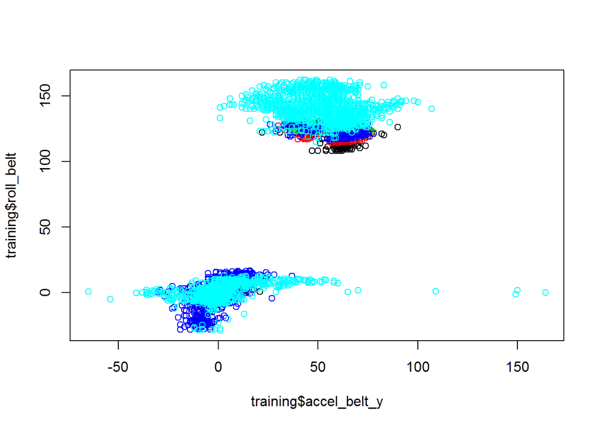

```r
## Plot correlated predictors
plot(training$accel_belt_y, training$roll_belt, col=training$classe)
```

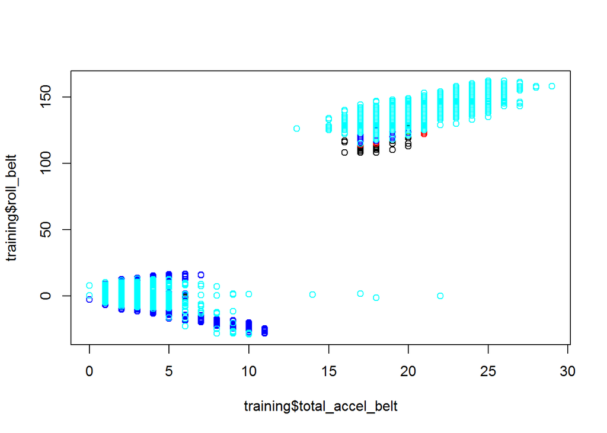

```r
plot(training$total_accel_belt, training$roll_belt, col=training$classe)
```

Recognizing that there were some correlated variables I then did some preprocessing to possibly further reduce the number of variables using a threshold of 95%.

```r
## Do some preprocessing of the data
preProcPC <- preProcess((training[,-53]+1),method="pca",thresh = 0.95)
trainingPC <- predict(preProcPC,training[,-53]+1)
```

This left me with just 26 variables. I then applyed the same preprocessing to the test set.

```r
## Apply the preprocessing to the test set
testingPC <- predict(preProcPC,(testing[,-60]+1))
```

```r
## eval=FALSE as it took a while for the model to run
## Fit a random forest model
modelFitRF <- train(training$classe ~ ., method="rf", data=trainingPC)
confusionMatrix(testing$classe,predict(modelFitRF,testingPC))
```

```r
## Apply model to 20 test cases
FINALTestPC <- predict(preProcPC,(FINALTest[,]+1))
predictions <- predict(modelFitRF,newdata = FINALTestPC, interval="prediction")
```